# Milestone Report

# Summary

# Data Summaries

Number of sentences in the first 50 text files and the average number of sentences across all 10,000 text files:

```r
nsentence(dat)[1:50]
```

```
##  text1  text2  text3  text4  text5  text6  text7  text8  text9 text10 text11
##      2      1      2      1      5      1      1      6     11      3      8
## text12 text13 text14 text15 text16 text17 text18 text19 text20 text21 text22
##      2      1      2      1      1      4      1      1      2      1      2
## text23 text24 text25 text26 text27 text28 text29 text30 text31 text32 text33
##      1      5      5      1      1      2      1      3      1      2      1
## text34 text35 text36 text37 text38 text39 text40 text41 text42 text43 text44
##      3      1      1      2      1      2      2      1      6      4      4
## text45 text46 text47 text48 text49 text50
##      1      1      4      2      2      1
```

```r
mean(nsentence(dat))
```

```
## [1] 2.6303
```

Below is a printout that shows what the document frequency term matrix looks like:

```r
dat_dfm[1:10,]
```

```
## Document-feature matrix of: 10 documents, 193,059 features (100.0% sparse).
##        features
## docs    bruschetta howev miss mark instead manag two-bit crostini huge slice
##   text1          1     1    1    1       1     1       1        1    1     1
##   text2          0     0    0    0       0     0       0        0    0     0
##   text3          0     0    0    0       0     0       0        0    0     0
##   text4          0     0    0    0       0     0       0        0    0     0
##   text5          0     0    0    0       0     0       0        0    0     0
##   text6          0     0    0    0       0     0       0        0    0     0
## [ reached max_ndoc ... 4 more documents, reached max_nfeat ... 193,049 more features ]
```

Most frequent features:

```r
topfeatures(dat_dfm, n = 100, decreasing = T)
```

```
##     one    like    time    just     get     can      go    make     day     use
##    1495    1249    1228    1120    1106    1072     944     869     779     753
##    year    know   thing    work    love     now   think   peopl    also    want
##     747     734     726     726     711     698     675     673     669     668
##     see    even    look     new    back    good   first     way    take    need
##     667     642     630     602     595     573     570     567     558     552
##    come     say      us    much    well    book  realli   littl   right     two
##     551     539     535     532     522     521     519     477     450     439
##    mani    feel    week    read   start  someth   still    life    said    made
##     434     425     423     422     419     405     402     402     397     395
##     tri    last    live  around   great  friend    find   place   never     may
##     394     379     374     370     360     352     346     345     338     331
##   world     got    help     god     lot    home    call   everi    post    blog
##     321     319     318     316     312     309     309     309     308     302
##   alway   anoth    sure    show    part     end   stori   write    seem    next
##     298     291     290     288     288     286     285     283     281     280
## thought    play    hope   chang    give     put     ask   today    long   point
##     278     278     276     274     274     274     270     269     262     262
##  actual    mean    sinc  person    word  differ  though    hous    tell   found
##     261     260     252     252     249     248     247     247     245     244
```

Least frequent features:

```r
topfeatures(dat_dfm, n = 50, decreasing = F)
```

```
##           two-bit          crostini        cannellini  bruschetta_howev
##                 1                 1                 1                 1
##        howev_miss         miss_mark      mark_instead     instead_manag
##                 1                 1                 1                 1
##     manag_two-bit  two-bit_crostini     crostini_huge        huge_slice
##                 1                 1                 1                 1
##       slice_grill       grill_bread        bread_heap          heap_top
##                 1                 1                 1                 1
##        top_tomato tomato_cannellini   cannellini_bean        bean_roast
##                 1                 1                 1                 1
##      roast_pepper       pepper_goat            walden           rainier
##                 1                 1                 1                 1
##          everglad       walden_pond           pond_mt        mt_rainier
##                 1                 1                 1                 1
##       rainier_big      sur_everglad    everglad_forth        despit_law
##                 1                 1                 1                 1
##           law_ban          ban_cell       phone_drive     drive_increas
##                 1                 1                 1                 1
##      increas_awar       awar_danger     danger_common       common_fact
##                 1                 1                 1                 1
##         fact_cell         phone_use       drive_still  still_widespread
##                 1                 1                 1                 1
## widespread_occurr     occurr_perhap  perhap_discourag    discourag_issu
##                 1                 1                 1                 1
##         issu_much     much_distract
##                 1                 1
```

Summary of first 9 text files:

```r
textstat_summary(dat_dfm)[1:10,]
```

```
##   document chars sents tokens types puncts numbers symbols urls tags emojis
## 1    text1    NA    NA     41    41      0       0       0    0    0      0
## 2    text2    NA    NA     15    15      0       0       0    0    0      0
## 3    text3    NA    NA     75    70      0       0       0    0    0      0
## 4    text4    NA    NA      3     3      0       0       0    0    0      0
## 5    text5    NA    NA     63    57      0       0       0    0    0      0
## 6    text6    NA    NA     13    13      0       0       0    0    0      0
## 7    text7    NA    NA     15    15      0       0       0    0    0      0
## 8    text8    NA    NA     61    60      0       0       0    0    0      0
## 9    text9    NA    NA    231   215      0       0       0    0    0      0
##  [ reached 'max' / getOption("max.print") -- omitted 1 rows ]
```

Summary of most frequent features:

```r
textstat_frequency(dat_dfm)[1:10,]
```

```
##    feature frequency rank docfreq group
## 1      one      1495    1    1207   all
## 2     like      1249    2    1030   all
## 3     time      1228    3    1003   all
## 4     just      1120    4     970   all
## 5      get      1106    5     925   all
## 6      can      1072    6     890   all
## 7       go       944    7     783   all
## 8     make       869    8     750   all
## 9      day       779    9     632   all
## 10     use       753   10     617   all
```

# Exploratory Analysis

## Word Cloud

100 most frequent words:

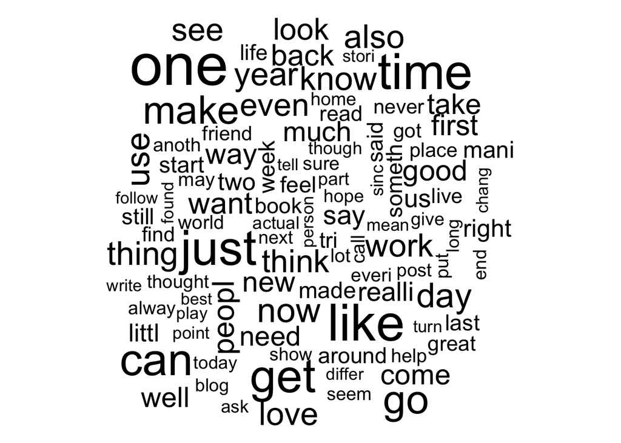

```r
# Word cloud, top words
dat_dfm_df %>%
  count(word) %>%
  with(wordcloud(word, n, max.words = 100))
```

## Most Frequent Words

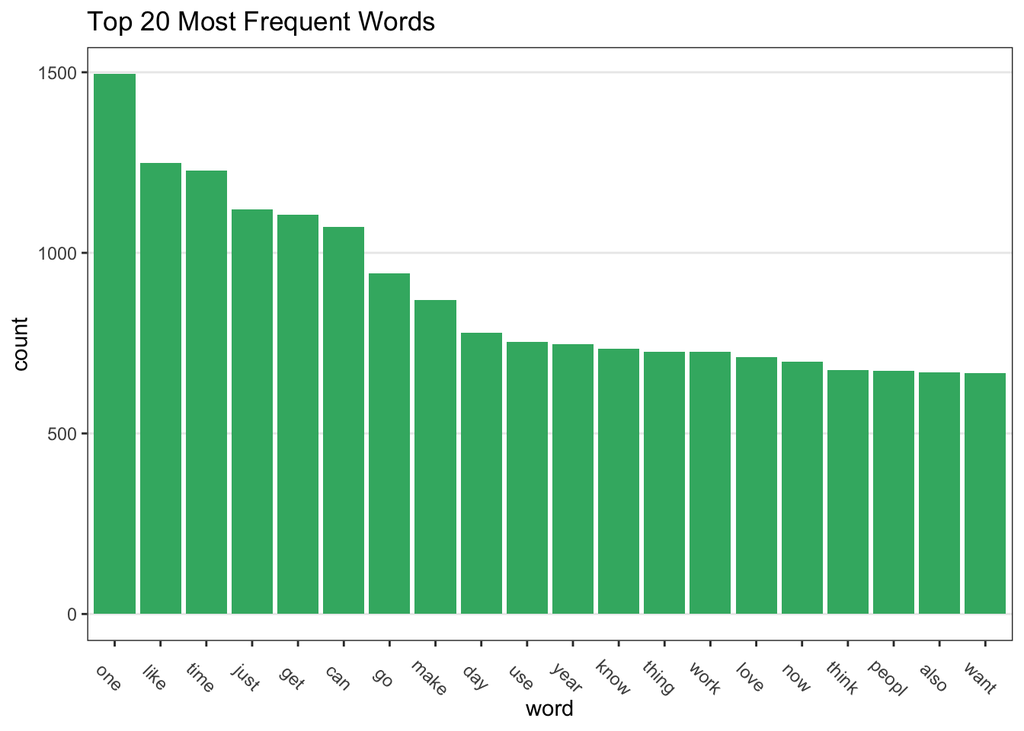

```r
# Bar chart, top words
data.frame(word = attributes(topfeatures(dat_dfm, n = 20))$names,
           count = topfeatures(dat_dfm, n = 20)) %>%
  mutate(word = fct_reorder(word, desc(count))) %>%
  ggplot(aes(word, count)) +
  geom_col(fill = "mediumseagreen") +
  theme_bw() +
  labs(title = "Top 20 Most Frequent Words") +
  theme(axis.text.x = element_text(angle = 315),
        panel.grid.minor.y = element_blank(),
        panel.grid.major.x = element_blank())
```

## Sentiment Analysis

### Most frequent positive and negative sentiments

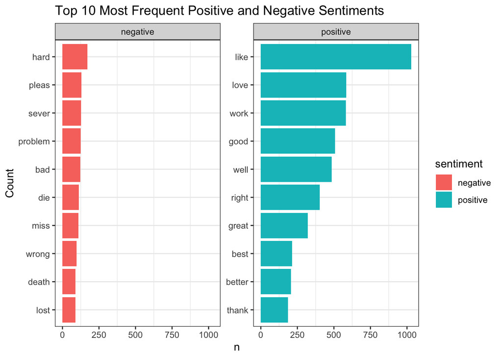

```r
## Top positive and negative
# Bing
dat_dfm_df %>%
  inner_join(get_sentiments("bing")) %>%
  count(word, sentiment, sort = TRUE) %>%
  group_by(sentiment) %>%
  mutate(word = fct_reorder(word, n)) %>%
  slice(1:10) %>%
  ggplot(aes(n, word, fill = sentiment)) +
  geom_col(position = "dodge") +
  facet_wrap(~sentiment, scales = "free_y") +
  labs(title = "Top 10 Most Frequent Positive and Negative Sentiments") +
  ylab("Count") +
  theme_bw() +
  theme(panel.grid.major.x = element_blank(),
        panel.grid.minor.y = element_blank())
```

### Most frequent words by sentiment

Top 3 most frequent words using the Afinn sentiment lexicon:

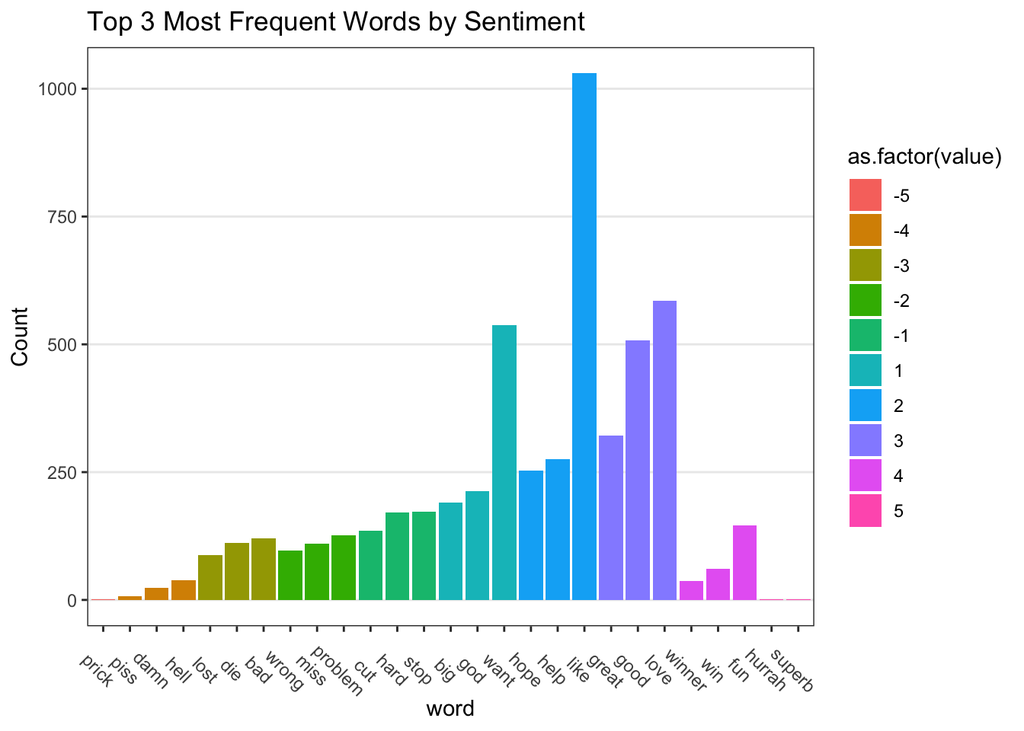

```r
# Top sentiments
## Afinn
dat_dfm_df %>%
  inner_join(get_sentiments("afinn")) %>%
  count(word, value, sort = TRUE) %>%
  group_by(value) %>%
  mutate(word = fct_reorder(word, n)) %>%
  slice(1:3) %>%
  ggplot(aes(word, n, fill = as.factor(value))) +
  geom_col(position = "dodge") +
  labs(title = "Top 3 Most Frequent Words by Sentiment") +
  ylab("Count") +
  theme_bw() +
  theme(axis.text.x = element_text(angle = 315),
        panel.grid.minor.y = element_blank(),
        panel.grid.major.x = element_blank())
```

Top 3 most frequent words using the Nrc sentiment lexicon:

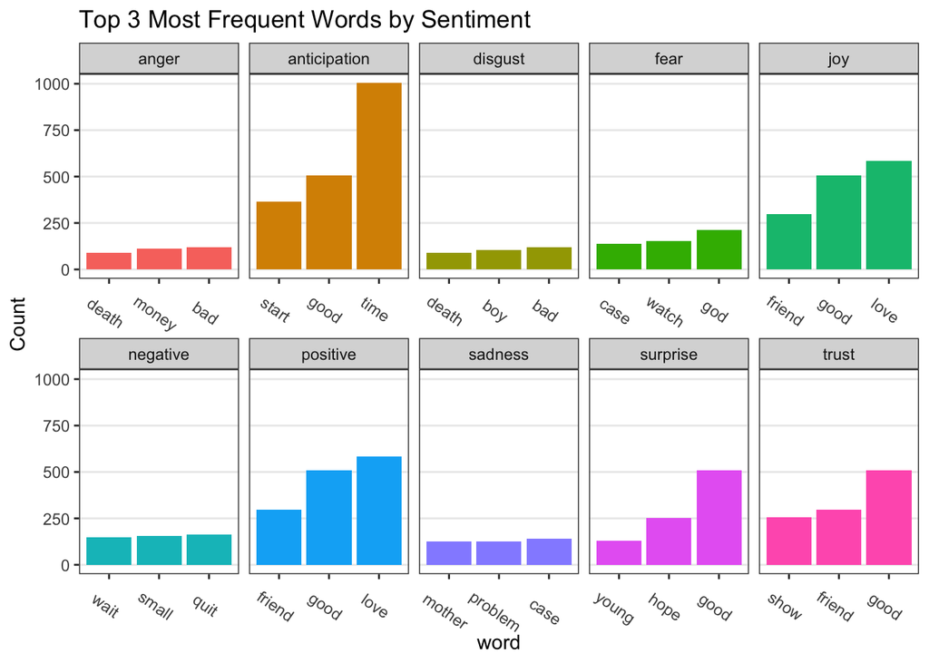

```r
# Top sentiments
## Nrc
  dat_dfm_df %>%
    inner_join(get_sentiments("nrc")) %>%
    count(word, sentiment, sort = TRUE) %>%
    mutate(word = fct_reorder(word, n)) %>%
    group_by(sentiment) %>%
    slice(1:3) %>%
    ggplot(aes(word, n, fill = as.factor(sentiment))) +
    geom_col(position = "dodge", show.legend = F) +
    facet_wrap(~sentiment, scales = "free_x", nrow = 2) +
    labs(title = "Top 3 Most Frequent Words by Sentiment") +
    ylab("Count") +
    theme_bw() +
    theme(panel.grid.minor.y = element_blank(),
          panel.grid.major.x = element_blank(),
          axis.text.x = element_text(angle = 325))
```

# Prediction Algorithm

For my prediction algorithm, I’ll be using the n-gram language model. Simply put, an n-gram is a sequence of n-words. For example, if I were to create a 2-gram model of the text, “You are nice”, the 2-gram model would be “you are” and “are nice”. Pairing words together like this allows for predictions. If you were to type the word “you”, the model in this situation would predict the next word to be “are”, because in our training set the word “you” is paired with the word “are”. Obviously, though, there will not always be a single pairing of words like this. There will sometimes be hundreds of word pairings; so what do you do in this situation? In this situation, you can predict the next word to be the word pairing *with the highest frequency* in the training set. For example, the word “you” may be paired with the words, “are”, “like”, “hate”, “look”, “seem”, etc. Whichever of these pairings occurs most frequently will be used for the prediction. If the word you type does not appear in the training data, and thus a word pair will not exist, the model will default to listing the highest frequency words as the predictions.